# Week 3 Exercise

# Locating files in R

Download this zip file containing another example RNA-seq dataset:-

- GSE100687.zip
1. Create a New Rstudio project for this dataset

Recall the code that we used to read the data for the Fibroblast data.

```r
library(tximport)
dirs <- list.files("salmon_quant/")
quant_files <- list.files("salmon_quant/",pattern="quant.sf.gz",recursive = TRUE,full.names = TRUE)
names(quant_files) <- dirs
txi <- tximport(quant_files,
                type="salmon",
                tx2gene = tx2gene,
                ignoreTxVersion = TRUE)
```

**Exercise** This code **will not work** on this new dataset. What changes do you need to make to the code to make it work?

- the directory `salmon_quant` needs to be changed to `salmon_output`.
- the `pattern` argument needs to be `quant.sf`

As we discovered in the practical, the `tx2gene.csv` file is used to aggregate the counts of different transcripts for the same gene. Follow the code below to read this file into R.

```r
library(readr)
tx2gene <- read_csv("tx2gene.csv",col_names = FALSE)
tx2gene
```

| X1 | X2 |
| --- | --- |
| ENST00000456328 | ENSG00000223972 |
| ENST00000450305 | ENSG00000223972 |
| ENST00000488147 | ENSG00000227232 |
| ENST00000619216 | ENSG00000278267 |
| ENST00000473358 | ENSG00000243485 |
| ENST00000469289 | ENSG00000243485 |
| ENST00000607096 | ENSG00000284332 |
| ENST00000417324 | ENSG00000237613 |
| ENST00000461467 | ENSG00000237613 |
| ENST00000606857 | ENSG00000268020 |

[output cut: 990 more lines]

**Exercise** As with the dataset presented in the practical, the meta data for this dataset can be found in the `meta_data` folder. Read these data into R using the appropriate function and save as a variable called `sampleInfo`. It should look like the example below

```r
sampleInfo <- read_tsv("meta_data/sampleInfo.txt")
sampleInfo
```

| SRR | GSE | CellLine | Treated |
| --- | --- | --- | --- |
| SRR5788492 | GSM2691343 | MCF-7 | N |
| SRR5788493 | GSM2691344 | MCF-7 | Y |
| SRR5788494 | GSM2691345 | SK-BR-3 | N |
| SRR5788495 | GSM2691346 | SK-BR-3 | Y |
| SRR5788496 | GSM2691347 | MDA-MB-231 | N |
| SRR5788497 | GSM2691348 | MDA-MB-231 | Y |

The full code to read the data is therefore

```r
dirs <- list.files("salmon_output/")
quant_files <- list.files("salmon_output/",pattern="quant.sf",recursive = TRUE,full.names = TRUE)
names(quant_files) <- dirs
txi <- tximport(quant_files,
                type="salmon",
                tx2gene = tx2gene,
                ignoreTxVersion = TRUE)
```

```
reading in files with read_tsv
1 2 3 4 5 6
summarizing abundance
summarizing counts
summarizing length
```

Now, proceed to create a `DESeq2` object for the dataset using the code below.

```r
library(DESeq2)
dds <- DESeqDataSetFromTximport(txi,
                                colData = sampleInfo,
                                design = ~CellLine)
```

```
  Note: levels of factors in the design contain characters other than
  letters, numbers, '_' and '.'. It is recommended (but not required) to use
  only letters, numbers, and delimiters '_' or '.', as these are safe characters
  for column names in R. [This is a message, not a warning or an error]
using counts and average transcript lengths from tximport
```

**Exercise**: - What is the total number of reads present for each sample? - Visualise the number of counts as a barplot, with different colours for each cell line and a horizontal line to indicate 3.5 million reads

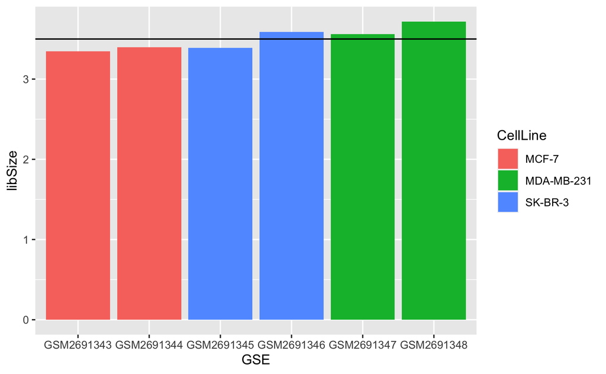

```r
sampleInfo %>%
  mutate(libSize = colSums(counts(dds))/1e6) %>%
  ggplot(aes(x = GSE, y = libSize,fill=CellLine)) + geom_col() + geom_hline(yintercept = 3.5)
```

Similar to the `colSums` function used in the previous exercise, there are also `rowMeans` and `rowSums` functions that can be applied to numerical matrices (such as the counts matrix).

**Exercise**: - What quantities are computed by applying the `rowMeans` and `rowSums` functions to the count matrix?

```r
rowMeans(counts(dds))
rowSums(counts(dds))
```

- How might the output of these functions be used to determine genes that are not expressed in our dataset?

`rowMeans` and `rowSums` give the average expression and total expression for each gene separately. Some workflows advocate removing genes with low expression in order to reduce the problem of multiple testing.

We can make a `table` of the `rowSums` output which will tell us how many genes are never sequenced:-

```r
table(rowSums(counts(dds)))[1:10]
```

```
    0     1     2     3     4     5     6     7     8
25440  4785  2435  1637  1117   916   766   571   554
    9
  457
```

Even though we have have over 50,000 rows in the data; nearly half of these are empty (zero counts) and will only add “noise” to our analysis

To visualise the means we can use a density plot on the `log2` transformed values.

This shows a large number of genes have very small counts, and another peak around 7 (which is 128 on the raw scale). There is quite a long tail with some genes having average counts of around 2^15.

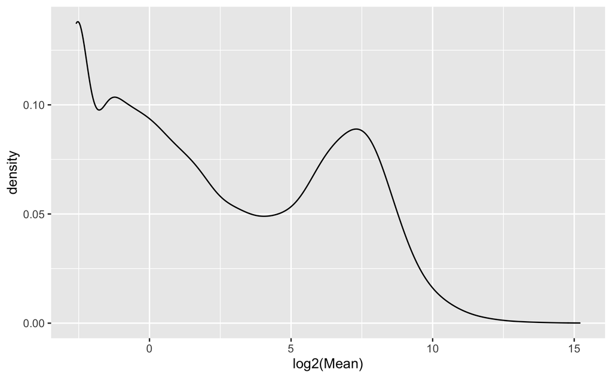

```r
data.frame(Mean = rowMeans(counts(dds))) %>%
  ggplot(aes(x = log2(Mean))) + geom_density()
```